# Risk Factor Analysis

## Outcome Variable

**Outcome Variable:** haz

## Predictor Variables

**Intervention Variable:** exclfeed3

**Adjustment Set:**

unadjusted

## Stratifying Variables

The analysis was stratified on these variable(s):

- agecat
- studyid
- country

## Data Summary

| agecat | studyid | country | exclfeed3 | n_cell | n |
| --- | --- | --- | --- | --- | --- |
| Birth | ki0047075b-MAL-ED | BANGLADESH | 1 | 173 | 240 |
| Birth | ki0047075b-MAL-ED | BANGLADESH | 0 | 67 | 240 |
| Birth | ki0047075b-MAL-ED | BRAZIL | 1 | 67 | 185 |
| Birth | ki0047075b-MAL-ED | BRAZIL | 0 | 118 | 185 |
| Birth | ki0047075b-MAL-ED | INDIA | 1 | 123 | 196 |
| Birth | ki0047075b-MAL-ED | INDIA | 0 | 73 | 196 |
| Birth | ki0047075b-MAL-ED | NEPAL | 1 | 61 | 171 |
| Birth | ki0047075b-MAL-ED | NEPAL | 0 | 110 | 171 |
| Birth | ki0047075b-MAL-ED | PERU | 1 | 67 | 272 |
| Birth | ki0047075b-MAL-ED | PERU | 0 | 205 | 272 |
| Birth | ki0047075b-MAL-ED | SOUTH AFRICA | 1 | 32 | 233 |
| Birth | ki0047075b-MAL-ED | SOUTH AFRICA | 0 | 201 | 233 |
| Birth | ki0047075b-MAL-ED | TANZANIA, UNITED REPUBLIC OF | 1 | 39 | 119 |
| Birth | ki0047075b-MAL-ED | TANZANIA, UNITED REPUBLIC OF | 0 | 80 | 119 |
| Birth | ki1000108-CMC-V-BCS-2002 | INDIA | 1 | 4 | 4 |
| Birth | ki1000108-CMC-V-BCS-2002 | INDIA | 0 | 0 | 4 |
| Birth | ki1000108-IRC | INDIA | 1 | 0 | 10 |
| Birth | ki1000108-IRC | INDIA | 0 | 10 | 10 |
| Birth | ki1000109-EE | PAKISTAN | 1 | 2 | 2 |
| Birth | ki1000109-EE | PAKISTAN | 0 | 0 | 2 |
| Birth | ki1000304b-SAS-CompFeed | INDIA | 1 | 48 | 50 |
| Birth | ki1000304b-SAS-CompFeed | INDIA | 0 | 2 | 50 |
| Birth | ki1101329-Keneba | GAMBIA | 1 | 1196 | 1354 |
| Birth | ki1101329-Keneba | GAMBIA | 0 | 158 | 1354 |
| Birth | kiGH5241-JiVitA-3 | BANGLADESH | 1 | 16824 | 18710 |
| Birth | kiGH5241-JiVitA-3 | BANGLADESH | 0 | 1886 | 18710 |
| Birth | kiGH5241-JiVitA-4 | BANGLADESH | 1 | 37 | 40 |
| Birth | kiGH5241-JiVitA-4 | BANGLADESH | 0 | 3 | 40 |
| 6 months | ki0047075b-MAL-ED | BANGLADESH | 1 | 172 | 237 |
| 6 months | ki0047075b-MAL-ED | BANGLADESH | 0 | 65 | 237 |

[output cut: 58 more lines]

The following strata were considered:

- agecat: 24 months, studyid: ki0047075b-MAL-ED, country: BANGLADESH
- agecat: 24 months, studyid: ki0047075b-MAL-ED, country: BRAZIL
- agecat: 24 months, studyid: ki0047075b-MAL-ED, country: INDIA
- agecat: 24 months, studyid: ki0047075b-MAL-ED, country: NEPAL
- agecat: 24 months, studyid: ki0047075b-MAL-ED, country: PERU
- agecat: 24 months, studyid: ki0047075b-MAL-ED, country: SOUTH AFRICA
- agecat: 24 months, studyid: ki0047075b-MAL-ED, country: TANZANIA, UNITED REPUBLIC OF
- agecat: 24 months, studyid: ki1000108-CMC-V-BCS-2002, country: INDIA
- agecat: 24 months, studyid: ki1000108-IRC, country: INDIA
- agecat: 24 months, studyid: ki1017093b-PROVIDE, country: BANGLADESH
- agecat: 24 months, studyid: ki1101329-Keneba, country: GAMBIA
- agecat: 24 months, studyid: ki1113344-GMS-Nepal, country: NEPAL
- agecat: 24 months, studyid: kiGH5241-JiVitA-3, country: BANGLADESH
- agecat: 24 months, studyid: kiGH5241-JiVitA-4, country: BANGLADESH
- agecat: 6 months, studyid: ki0047075b-MAL-ED, country: BANGLADESH
- agecat: 6 months, studyid: ki0047075b-MAL-ED, country: BRAZIL
- agecat: 6 months, studyid: ki0047075b-MAL-ED, country: INDIA
- agecat: 6 months, studyid: ki0047075b-MAL-ED, country: NEPAL
- agecat: 6 months, studyid: ki0047075b-MAL-ED, country: PERU
- agecat: 6 months, studyid: ki0047075b-MAL-ED, country: SOUTH AFRICA
- agecat: 6 months, studyid: ki0047075b-MAL-ED, country: TANZANIA, UNITED REPUBLIC OF
- agecat: 6 months, studyid: ki1000108-CMC-V-BCS-2002, country: INDIA
- agecat: 6 months, studyid: ki1000108-IRC, country: INDIA
- agecat: 6 months, studyid: ki1000109-EE, country: PAKISTAN
- agecat: 6 months, studyid: ki1000304b-SAS-CompFeed, country: INDIA
- agecat: 6 months, studyid: ki1017093b-PROVIDE, country: BANGLADESH
- agecat: 6 months, studyid: ki1101329-Keneba, country: GAMBIA
- agecat: 6 months, studyid: ki1113344-GMS-Nepal, country: NEPAL
- agecat: 6 months, studyid: kiGH5241-JiVitA-3, country: BANGLADESH
- agecat: 6 months, studyid: kiGH5241-JiVitA-4, country: BANGLADESH
- agecat: Birth, studyid: ki0047075b-MAL-ED, country: BANGLADESH
- agecat: Birth, studyid: ki0047075b-MAL-ED, country: BRAZIL
- agecat: Birth, studyid: ki0047075b-MAL-ED, country: INDIA
- agecat: Birth, studyid: ki0047075b-MAL-ED, country: NEPAL
- agecat: Birth, studyid: ki0047075b-MAL-ED, country: PERU
- agecat: Birth, studyid: ki0047075b-MAL-ED, country: SOUTH AFRICA
- agecat: Birth, studyid: ki0047075b-MAL-ED, country: TANZANIA, UNITED REPUBLIC OF
- agecat: Birth, studyid: ki1000108-CMC-V-BCS-2002, country: INDIA
- agecat: Birth, studyid: ki1000108-IRC, country: INDIA
- agecat: Birth, studyid: ki1000109-EE, country: PAKISTAN
- agecat: Birth, studyid: ki1000304b-SAS-CompFeed, country: INDIA
- agecat: Birth, studyid: ki1101329-Keneba, country: GAMBIA
- agecat: Birth, studyid: kiGH5241-JiVitA-3, country: BANGLADESH
- agecat: Birth, studyid: kiGH5241-JiVitA-4, country: BANGLADESH

### Dropped Strata

Some strata were dropped due to rare outcomes:

- agecat: Birth, studyid: ki1000108-CMC-V-BCS-2002, country: INDIA
- agecat: Birth, studyid: ki1000108-IRC, country: INDIA
- agecat: Birth, studyid: ki1000109-EE, country: PAKISTAN
- agecat: Birth, studyid: ki1000304b-SAS-CompFeed, country: INDIA
- agecat: Birth, studyid: kiGH5241-JiVitA-4, country: BANGLADESH
- agecat: 6 months, studyid: ki1000108-CMC-V-BCS-2002, country: INDIA
- agecat: 6 months, studyid: ki1000108-IRC, country: INDIA
- agecat: 24 months, studyid: ki1000108-CMC-V-BCS-2002, country: INDIA
- agecat: 24 months, studyid: ki1000108-IRC, country: INDIA

## Methods Detail

We’re interested in the causal parameters $E[Y_a]$ for all values of $a \in \mathcal{A}$. These parameters represent the mean outcome if, possibly contrary to fact, we intervened to set all units to have $A=a$. Under the randomization and positivity assumptions, these are identified by the statistical parameters $\psi_a=E_W[E_{Y|A,W}(Y|A=a,W)]$. In addition, we’re interested in the mean of $Y$, $E[Y]$ under no intervention (the observed mean). We will estimate these parameters by using SuperLearner to fit the relevant likelihood factors – $E_{Y|A,W}(Y|A=a,W)$ and $p(A=a|W)$, and then updating our likelihood fit using a joint TMLE.

For unadjusted analyses ($W=\{\}$), initial likelihoods were estimated using Lrnr_glm to estimate the simple $E(Y|A)$ and Lrnr_mean to estimate $p(A)$. For adjusted analyses, a small library containing Lrnr_glmnet, Lrnr_xgboost, and Lrnr_mean was used.

Having estimated these parameters, we will then use the delta method to estimate relative risks and attributable risks relative to a prespecified baseline level of $A$.

# Results Detail

## Results Plots

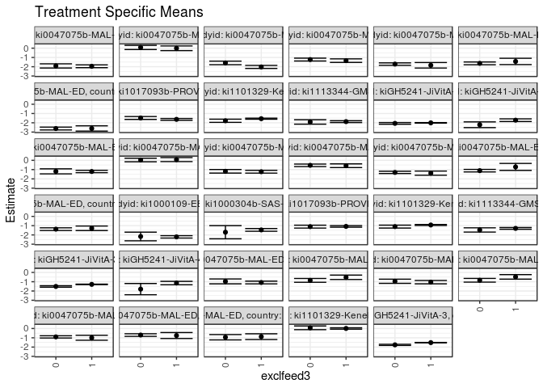

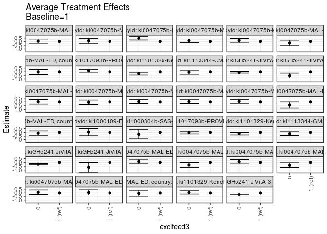

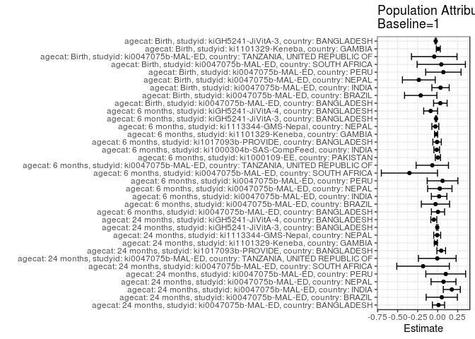

## Results Table

### Parameter: TSM

| agecat | studyid | country | intervention_level | baseline_level | estimate | ci_lower | ci_upper |
| --- | --- | --- | --- | --- | --- | --- | --- |
| Birth | ki0047075b-MAL-ED | BANGLADESH | 1 | NA | -1.0830636 | -1.2286468 | -0.9374804 |
| Birth | ki0047075b-MAL-ED | BANGLADESH | 0 | NA | -0.9635821 | -1.2274311 | -0.6997330 |
| Birth | ki0047075b-MAL-ED | BRAZIL | 1 | NA | -0.5231343 | -0.7589548 | -0.2873138 |
| Birth | ki0047075b-MAL-ED | BRAZIL | 0 | NA | -0.8554237 | -1.0630953 | -0.6477521 |
| Birth | ki0047075b-MAL-ED | INDIA | 1 | NA | -1.0456911 | -1.2278679 | -0.8635142 |
| Birth | ki0047075b-MAL-ED | INDIA | 0 | NA | -0.9494521 | -1.1754145 | -0.7234897 |
| Birth | ki0047075b-MAL-ED | NEPAL | 1 | NA | -0.4775410 | -0.7220199 | -0.2330621 |
| Birth | ki0047075b-MAL-ED | NEPAL | 0 | NA | -0.8432727 | -1.0433537 | -0.6431918 |
| Birth | ki0047075b-MAL-ED | PERU | 1 | NA | -0.9974627 | -1.2647488 | -0.7301765 |
| Birth | ki0047075b-MAL-ED | PERU | 0 | NA | -0.9028293 | -1.0241264 | -0.7815322 |
| Birth | ki0047075b-MAL-ED | SOUTH AFRICA | 1 | NA | -0.7559375 | -1.0764717 | -0.4354033 |
| Birth | ki0047075b-MAL-ED | SOUTH AFRICA | 0 | NA | -0.7036816 | -0.8432205 | -0.5641427 |
| Birth | ki0047075b-MAL-ED | TANZANIA, UNITED REPUBLIC OF | 1 | NA | -0.8779487 | -1.1870339 | -0.5688636 |
| Birth | ki0047075b-MAL-ED | TANZANIA, UNITED REPUBLIC OF | 0 | NA | -0.9413750 | -1.2298285 | -0.6529215 |
| Birth | ki1101329-Keneba | GAMBIA | 1 | NA | 0.0055686 | -0.0685374 | 0.0796746 |
| Birth | ki1101329-Keneba | GAMBIA | 0 | NA | 0.0736076 | -0.1262423 | 0.2734575 |
| Birth | kiGH5241-JiVitA-3 | BANGLADESH | 1 | NA | -1.5215680 | -1.5414081 | -1.5017279 |
| Birth | kiGH5241-JiVitA-3 | BANGLADESH | 0 | NA | -1.7614581 | -1.8262256 | -1.6966906 |
| 6 months | ki0047075b-MAL-ED | BANGLADESH | 1 | NA | -1.2050388 | -1.3328992 | -1.0771783 |
| 6 months | ki0047075b-MAL-ED | BANGLADESH | 0 | NA | -1.1902051 | -1.4617021 | -0.9187082 |
| 6 months | ki0047075b-MAL-ED | BRAZIL | 1 | NA | 0.0782099 | -0.1367615 | 0.2931812 |
| 6 months | ki0047075b-MAL-ED | BRAZIL | 0 | NA | 0.0338151 | -0.1579806 | 0.2256108 |
| 6 months | ki0047075b-MAL-ED | INDIA | 1 | NA | -1.2288534 | -1.3799536 | -1.0777532 |
| 6 months | ki0047075b-MAL-ED | INDIA | 0 | NA | -1.1835145 | -1.3766499 | -0.9903790 |
| 6 months | ki0047075b-MAL-ED | NEPAL | 1 | NA | -0.5826471 | -0.7805040 | -0.3847901 |
| 6 months | ki0047075b-MAL-ED | NEPAL | 0 | NA | -0.5403716 | -0.6757754 | -0.4049678 |
| 6 months | ki0047075b-MAL-ED | PERU | 1 | NA | -1.3837313 | -1.6067986 | -1.1606640 |
| 6 months | ki0047075b-MAL-ED | PERU | 0 | NA | -1.3028407 | -1.4257599 | -1.1799216 |
| 6 months | ki0047075b-MAL-ED | SOUTH AFRICA | 1 | NA | -0.7110753 | -1.0874941 | -0.3346564 |
| 6 months | ki0047075b-MAL-ED | SOUTH AFRICA | 0 | NA | -1.1144585 | -1.2513122 | -0.9776048 |
| 6 months | ki0047075b-MAL-ED | TANZANIA, UNITED REPUBLIC OF | 1 | NA | -1.2845588 | -1.5266595 | -1.0424581 |
| 6 months | ki0047075b-MAL-ED | TANZANIA, UNITED REPUBLIC OF | 0 | NA | -1.3781686 | -1.5236819 | -1.2326554 |
| 6 months | ki1000109-EE | PAKISTAN | 1 | NA | -2.2085405 | -2.3358767 | -2.0812042 |
| 6 months | ki1000109-EE | PAKISTAN | 0 | NA | -2.1658000 | -2.6320343 | -1.6995657 |
| 6 months | ki1000304b-SAS-CompFeed | INDIA | 1 | NA | -1.4578628 | -1.6049871 | -1.3107385 |
| 6 months | ki1000304b-SAS-CompFeed | INDIA | 0 | NA | -1.7063158 | -2.4149433 | -0.9976883 |
| 6 months | ki1017093b-PROVIDE | BANGLADESH | 1 | NA | -1.0799312 | -1.1660089 | -0.9938536 |
| 6 months | ki1017093b-PROVIDE | BANGLADESH | 0 | NA | -1.1043860 | -1.2622300 | -0.9465419 |
| 6 months | ki1101329-Keneba | GAMBIA | 1 | NA | -0.9291579 | -0.9832318 | -0.8750840 |
| 6 months | ki1101329-Keneba | GAMBIA | 0 | NA | -1.1005307 | -1.2581027 | -0.9429587 |
| 6 months | ki1113344-GMS-Nepal | NEPAL | 1 | NA | -1.2945646 | -1.3876531 | -1.2014762 |
| 6 months | ki1113344-GMS-Nepal | NEPAL | 0 | NA | -1.4624895 | -1.6925949 | -1.2323840 |
| 6 months | kiGH5241-JiVitA-3 | BANGLADESH | 1 | NA | -1.2855652 | -1.3089244 | -1.2622060 |
| 6 months | kiGH5241-JiVitA-3 | BANGLADESH | 0 | NA | -1.5093083 | -1.5868939 | -1.4317226 |
| 6 months | kiGH5241-JiVitA-4 | BANGLADESH | 1 | NA | -1.1459740 | -1.3308960 | -0.9610521 |
| 6 months | kiGH5241-JiVitA-4 | BANGLADESH | 0 | NA | -1.7983333 | -2.4033116 | -1.1933551 |
| 24 months | ki0047075b-MAL-ED | BANGLADESH | 1 | NA | -1.9496333 | -2.1032163 | -1.7960503 |
| 24 months | ki0047075b-MAL-ED | BANGLADESH | 0 | NA | -1.9120690 | -2.1375979 | -1.6865400 |
| 24 months | ki0047075b-MAL-ED | BRAZIL | 1 | NA | -0.0093662 | -0.2604193 | 0.2416869 |
| 24 months | ki0047075b-MAL-ED | BRAZIL | 0 | NA | 0.0789286 | -0.1445509 | 0.3024081 |
| 24 months | ki0047075b-MAL-ED | INDIA | 1 | NA | -2.0200752 | -2.1835228 | -1.8566276 |
| 24 months | ki0047075b-MAL-ED | INDIA | 0 | NA | -1.5878804 | -1.7780817 | -1.3976792 |
| 24 months | ki0047075b-MAL-ED | NEPAL | 1 | NA | -1.3423780 | -1.5325387 | -1.1522174 |
| 24 months | ki0047075b-MAL-ED | NEPAL | 0 | NA | -1.2275175 | -1.3817020 | -1.0733330 |
| 24 months | ki0047075b-MAL-ED | PERU | 1 | NA | -1.8447826 | -2.1410297 | -1.5485356 |
| 24 months | ki0047075b-MAL-ED | PERU | 0 | NA | -1.7137255 | -1.8428203 | -1.5846307 |
| 24 months | ki0047075b-MAL-ED | SOUTH AFRICA | 1 | NA | -1.4290741 | -1.7694961 | -1.0886521 |
| 24 months | ki0047075b-MAL-ED | SOUTH AFRICA | 0 | NA | -1.6354634 | -1.7837944 | -1.4871324 |
| 24 months | ki0047075b-MAL-ED | TANZANIA, UNITED REPUBLIC OF | 1 | NA | -2.6110526 | -2.8950358 | -2.3270695 |
| 24 months | ki0047075b-MAL-ED | TANZANIA, UNITED REPUBLIC OF | 0 | NA | -2.6178105 | -2.7725634 | -2.4630575 |
| 24 months | ki1017093b-PROVIDE | BANGLADESH | 1 | NA | -1.6304668 | -1.7289380 | -1.5319957 |
| 24 months | ki1017093b-PROVIDE | BANGLADESH | 0 | NA | -1.4799412 | -1.6345304 | -1.3253520 |
| 24 months | ki1101329-Keneba | GAMBIA | 1 | NA | -1.5574617 | -1.6146781 | -1.5002452 |
| 24 months | ki1101329-Keneba | GAMBIA | 0 | NA | -1.7812295 | -1.9536050 | -1.6088539 |
| 24 months | ki1113344-GMS-Nepal | NEPAL | 1 | NA | -1.8727976 | -1.9717463 | -1.7738489 |
| 24 months | ki1113344-GMS-Nepal | NEPAL | 0 | NA | -1.9084804 | -2.1468994 | -1.6700614 |
| 24 months | kiGH5241-JiVitA-3 | BANGLADESH | 1 | NA | -2.0056791 | -2.0347010 | -1.9766573 |
| 24 months | kiGH5241-JiVitA-3 | BANGLADESH | 0 | NA | -2.0613592 | -2.1526919 | -1.9700265 |
| 24 months | kiGH5241-JiVitA-4 | BANGLADESH | 1 | NA | -1.7186131 | -1.8623416 | -1.5748846 |
| 24 months | kiGH5241-JiVitA-4 | BANGLADESH | 0 | NA | -2.2100000 | -2.5176955 | -1.9023045 |

### Parameter: E(Y)

| agecat | studyid | country | intervention_level | baseline_level | estimate | ci_lower | ci_upper |
| --- | --- | --- | --- | --- | --- | --- | --- |
| Birth | ki0047075b-MAL-ED | BANGLADESH | NA | NA | -1.0497083 | -1.1780996 | -0.9213171 |
| Birth | ki0047075b-MAL-ED | BRAZIL | NA | NA | -0.7350811 | -0.8943683 | -0.5757938 |
| Birth | ki0047075b-MAL-ED | INDIA | NA | NA | -1.0098469 | -1.1519586 | -0.8677353 |
| Birth | ki0047075b-MAL-ED | NEPAL | NA | NA | -0.7128070 | -0.8704934 | -0.5551207 |
| Birth | ki0047075b-MAL-ED | PERU | NA | NA | -0.9261397 | -1.0389037 | -0.8133757 |
| Birth | ki0047075b-MAL-ED | SOUTH AFRICA | NA | NA | -0.7108584 | -0.8390511 | -0.5826657 |
| Birth | ki0047075b-MAL-ED | TANZANIA, UNITED REPUBLIC OF | NA | NA | -0.9205882 | -1.1394357 | -0.7017408 |
| Birth | ki1101329-Keneba | GAMBIA | NA | NA | 0.0135081 | -0.0559902 | 0.0830065 |
| Birth | kiGH5241-JiVitA-3 | BANGLADESH | NA | NA | -1.5457493 | -1.5650991 | -1.5263996 |
| 6 months | ki0047075b-MAL-ED | BANGLADESH | NA | NA | -1.2009705 | -1.3199485 | -1.0819924 |
| 6 months | ki0047075b-MAL-ED | BRAZIL | NA | NA | 0.0510207 | -0.0930194 | 0.1950608 |
| 6 months | ki0047075b-MAL-ED | INDIA | NA | NA | -1.2109514 | -1.3300505 | -1.0918522 |
| 6 months | ki0047075b-MAL-ED | NEPAL | NA | NA | -0.5557940 | -0.6681063 | -0.4434817 |
| 6 months | ki0047075b-MAL-ED | PERU | NA | NA | -1.3229136 | -1.4307207 | -1.2151065 |
| 6 months | ki0047075b-MAL-ED | SOUTH AFRICA | NA | NA | -1.0640356 | -1.1937663 | -0.9343049 |
| 6 months | ki0047075b-MAL-ED | TANZANIA, UNITED REPUBLIC OF | NA | NA | -1.3516458 | -1.4765824 | -1.2267092 |
| 6 months | ki1000109-EE | PAKISTAN | NA | NA | -2.2056604 | -2.3285064 | -2.0828144 |
| 6 months | ki1000304b-SAS-CompFeed | INDIA | NA | NA | -1.4697236 | -1.6333919 | -1.3060553 |
| 6 months | ki1017093b-PROVIDE | BANGLADESH | NA | NA | -1.0871041 | -1.1635539 | -1.0106543 |
| 6 months | ki1101329-Keneba | GAMBIA | NA | NA | -0.9489317 | -1.0001696 | -0.8976937 |
| 6 months | ki1113344-GMS-Nepal | NEPAL | NA | NA | -1.3235298 | -1.4103807 | -1.2366790 |
| 6 months | kiGH5241-JiVitA-3 | BANGLADESH | NA | NA | -1.3060279 | -1.3292905 | -1.2827653 |
| 6 months | kiGH5241-JiVitA-4 | BANGLADESH | NA | NA | -1.2339326 | -1.4137041 | -1.0541611 |
| 24 months | ki0047075b-MAL-ED | BANGLADESH | NA | NA | -1.9391587 | -2.0665449 | -1.8117724 |
| 24 months | ki0047075b-MAL-ED | BRAZIL | NA | NA | 0.0418343 | -0.1253834 | 0.2090521 |
| 24 months | ki0047075b-MAL-ED | INDIA | NA | NA | -1.8433556 | -1.9704665 | -1.7162446 |
| 24 months | ki0047075b-MAL-ED | NEPAL | NA | NA | -1.2693778 | -1.3896188 | -1.1491367 |
| 24 months | ki0047075b-MAL-ED | PERU | NA | NA | -1.7440201 | -1.8648503 | -1.6231899 |
| 24 months | ki0047075b-MAL-ED | SOUTH AFRICA | NA | NA | -1.6114440 | -1.7486349 | -1.4742530 |
| 24 months | ki0047075b-MAL-ED | TANZANIA, UNITED REPUBLIC OF | NA | NA | -2.6159762 | -2.7525555 | -2.4793968 |
| 24 months | ki1017093b-PROVIDE | BANGLADESH | NA | NA | -1.5861179 | -1.6693668 | -1.5028689 |
| 24 months | ki1101329-Keneba | GAMBIA | NA | NA | -1.5804688 | -1.6348908 | -1.5260468 |
| 24 months | ki1113344-GMS-Nepal | NEPAL | NA | NA | -1.8788036 | -1.9703700 | -1.7872372 |
| 24 months | kiGH5241-JiVitA-3 | BANGLADESH | NA | NA | -2.0111797 | -2.0396837 | -1.9826758 |
| 24 months | kiGH5241-JiVitA-4 | BANGLADESH | NA | NA | -1.7671053 | -1.9017670 | -1.6324435 |

### Parameter: ATE

| agecat | studyid | country | intervention_level | baseline_level | estimate | ci_lower | ci_upper |
| --- | --- | --- | --- | --- | --- | --- | --- |
| Birth | ki0047075b-MAL-ED | BANGLADESH | 1 | 1 | 0.0000000 | 0.0000000 | 0.0000000 |
| Birth | ki0047075b-MAL-ED | BANGLADESH | 0 | 1 | 0.1194815 | -0.1818668 | 0.4208298 |
| Birth | ki0047075b-MAL-ED | BRAZIL | 1 | 1 | 0.0000000 | 0.0000000 | 0.0000000 |
| Birth | ki0047075b-MAL-ED | BRAZIL | 0 | 1 | -0.3322894 | -0.6465167 | -0.0180621 |
| Birth | ki0047075b-MAL-ED | INDIA | 1 | 1 | 0.0000000 | 0.0000000 | 0.0000000 |
| Birth | ki0047075b-MAL-ED | INDIA | 0 | 1 | 0.0962390 | -0.1940151 | 0.3864931 |
| Birth | ki0047075b-MAL-ED | NEPAL | 1 | 1 | 0.0000000 | 0.0000000 | 0.0000000 |
| Birth | ki0047075b-MAL-ED | NEPAL | 0 | 1 | -0.3657317 | -0.6816468 | -0.0498167 |
| Birth | ki0047075b-MAL-ED | PERU | 1 | 1 | 0.0000000 | 0.0000000 | 0.0000000 |
| Birth | ki0047075b-MAL-ED | PERU | 0 | 1 | 0.0946334 | -0.1988881 | 0.3881549 |
| Birth | ki0047075b-MAL-ED | SOUTH AFRICA | 1 | 1 | 0.0000000 | 0.0000000 | 0.0000000 |
| Birth | ki0047075b-MAL-ED | SOUTH AFRICA | 0 | 1 | 0.0522559 | -0.2973343 | 0.4018461 |
| Birth | ki0047075b-MAL-ED | TANZANIA, UNITED REPUBLIC OF | 1 | 1 | 0.0000000 | 0.0000000 | 0.0000000 |
| Birth | ki0047075b-MAL-ED | TANZANIA, UNITED REPUBLIC OF | 0 | 1 | -0.0634263 | -0.4862017 | 0.3593491 |
| Birth | ki1101329-Keneba | GAMBIA | 1 | 1 | 0.0000000 | 0.0000000 | 0.0000000 |
| Birth | ki1101329-Keneba | GAMBIA | 0 | 1 | 0.0680390 | -0.1451081 | 0.2811861 |
| Birth | kiGH5241-JiVitA-3 | BANGLADESH | 1 | 1 | 0.0000000 | 0.0000000 | 0.0000000 |
| Birth | kiGH5241-JiVitA-3 | BANGLADESH | 0 | 1 | -0.2398901 | -0.3064245 | -0.1733557 |
| 6 months | ki0047075b-MAL-ED | BANGLADESH | 1 | 1 | 0.0000000 | 0.0000000 | 0.0000000 |
| 6 months | ki0047075b-MAL-ED | BANGLADESH | 0 | 1 | 0.0148336 | -0.2852645 | 0.3149318 |
| 6 months | ki0047075b-MAL-ED | BRAZIL | 1 | 1 | 0.0000000 | 0.0000000 | 0.0000000 |
| 6 months | ki0047075b-MAL-ED | BRAZIL | 0 | 1 | -0.0443948 | -0.3324890 | 0.2436994 |
| 6 months | ki0047075b-MAL-ED | INDIA | 1 | 1 | 0.0000000 | 0.0000000 | 0.0000000 |
| 6 months | ki0047075b-MAL-ED | INDIA | 0 | 1 | 0.0453389 | -0.1998805 | 0.2905584 |
| 6 months | ki0047075b-MAL-ED | NEPAL | 1 | 1 | 0.0000000 | 0.0000000 | 0.0000000 |
| 6 months | ki0047075b-MAL-ED | NEPAL | 0 | 1 | 0.0422754 | -0.1974777 | 0.2820286 |
| 6 months | ki0047075b-MAL-ED | PERU | 1 | 1 | 0.0000000 | 0.0000000 | 0.0000000 |
| 6 months | ki0047075b-MAL-ED | PERU | 0 | 1 | 0.0808906 | -0.1738016 | 0.3355829 |
| 6 months | ki0047075b-MAL-ED | SOUTH AFRICA | 1 | 1 | 0.0000000 | 0.0000000 | 0.0000000 |
| 6 months | ki0047075b-MAL-ED | SOUTH AFRICA | 0 | 1 | -0.4033833 | -0.8039080 | -0.0028585 |
| 6 months | ki0047075b-MAL-ED | TANZANIA, UNITED REPUBLIC OF | 1 | 1 | 0.0000000 | 0.0000000 | 0.0000000 |
| 6 months | ki0047075b-MAL-ED | TANZANIA, UNITED REPUBLIC OF | 0 | 1 | -0.0936098 | -0.3760754 | 0.1888559 |
| 6 months | ki1000109-EE | PAKISTAN | 1 | 1 | 0.0000000 | 0.0000000 | 0.0000000 |
| 6 months | ki1000109-EE | PAKISTAN | 0 | 1 | 0.0427405 | -0.4405699 | 0.5260508 |
| 6 months | ki1000304b-SAS-CompFeed | INDIA | 1 | 1 | 0.0000000 | 0.0000000 | 0.0000000 |
| 6 months | ki1000304b-SAS-CompFeed | INDIA | 0 | 1 | -0.2484530 | -0.9061015 | 0.4091955 |
| 6 months | ki1017093b-PROVIDE | BANGLADESH | 1 | 1 | 0.0000000 | 0.0000000 | 0.0000000 |
| 6 months | ki1017093b-PROVIDE | BANGLADESH | 0 | 1 | -0.0244547 | -0.2042438 | 0.1553344 |
| 6 months | ki1101329-Keneba | GAMBIA | 1 | 1 | 0.0000000 | 0.0000000 | 0.0000000 |
| 6 months | ki1101329-Keneba | GAMBIA | 0 | 1 | -0.1713728 | -0.3379649 | -0.0047807 |
| 6 months | ki1113344-GMS-Nepal | NEPAL | 1 | 1 | 0.0000000 | 0.0000000 | 0.0000000 |
| 6 months | ki1113344-GMS-Nepal | NEPAL | 0 | 1 | -0.1679248 | -0.4161465 | 0.0802969 |
| 6 months | kiGH5241-JiVitA-3 | BANGLADESH | 1 | 1 | 0.0000000 | 0.0000000 | 0.0000000 |
| 6 months | kiGH5241-JiVitA-3 | BANGLADESH | 0 | 1 | -0.2237431 | -0.3014558 | -0.1460304 |
| 6 months | kiGH5241-JiVitA-4 | BANGLADESH | 1 | 1 | 0.0000000 | 0.0000000 | 0.0000000 |
| 6 months | kiGH5241-JiVitA-4 | BANGLADESH | 0 | 1 | -0.6523593 | -1.2845608 | -0.0201578 |
| 24 months | ki0047075b-MAL-ED | BANGLADESH | 1 | 1 | 0.0000000 | 0.0000000 | 0.0000000 |
| 24 months | ki0047075b-MAL-ED | BANGLADESH | 0 | 1 | 0.0375644 | -0.2352928 | 0.3104215 |
| 24 months | ki0047075b-MAL-ED | BRAZIL | 1 | 1 | 0.0000000 | 0.0000000 | 0.0000000 |
| 24 months | ki0047075b-MAL-ED | BRAZIL | 0 | 1 | 0.0882948 | -0.2478164 | 0.4244060 |
| 24 months | ki0047075b-MAL-ED | INDIA | 1 | 1 | 0.0000000 | 0.0000000 | 0.0000000 |
| 24 months | ki0047075b-MAL-ED | INDIA | 0 | 1 | 0.4321948 | 0.1814127 | 0.6829768 |
| 24 months | ki0047075b-MAL-ED | NEPAL | 1 | 1 | 0.0000000 | 0.0000000 | 0.0000000 |
| 24 months | ki0047075b-MAL-ED | NEPAL | 0 | 1 | 0.1148606 | -0.1299536 | 0.3596747 |
| 24 months | ki0047075b-MAL-ED | PERU | 1 | 1 | 0.0000000 | 0.0000000 | 0.0000000 |
| 24 months | ki0047075b-MAL-ED | PERU | 0 | 1 | 0.1310571 | -0.1920958 | 0.4542100 |
| 24 months | ki0047075b-MAL-ED | SOUTH AFRICA | 1 | 1 | 0.0000000 | 0.0000000 | 0.0000000 |
| 24 months | ki0047075b-MAL-ED | SOUTH AFRICA | 0 | 1 | -0.2063893 | -0.5777237 | 0.1649451 |
| 24 months | ki0047075b-MAL-ED | TANZANIA, UNITED REPUBLIC OF | 1 | 1 | 0.0000000 | 0.0000000 | 0.0000000 |
| 24 months | ki0047075b-MAL-ED | TANZANIA, UNITED REPUBLIC OF | 0 | 1 | -0.0067578 | -0.3301692 | 0.3166536 |
| 24 months | ki1017093b-PROVIDE | BANGLADESH | 1 | 1 | 0.0000000 | 0.0000000 | 0.0000000 |
| 24 months | ki1017093b-PROVIDE | BANGLADESH | 0 | 1 | 0.1505257 | -0.0327621 | 0.3338134 |
| 24 months | ki1101329-Keneba | GAMBIA | 1 | 1 | 0.0000000 | 0.0000000 | 0.0000000 |
| 24 months | ki1101329-Keneba | GAMBIA | 0 | 1 | -0.2237678 | -0.4053912 | -0.0421444 |
| 24 months | ki1113344-GMS-Nepal | NEPAL | 1 | 1 | 0.0000000 | 0.0000000 | 0.0000000 |
| 24 months | ki1113344-GMS-Nepal | NEPAL | 0 | 1 | -0.0356828 | -0.2938193 | 0.2224538 |
| 24 months | kiGH5241-JiVitA-3 | BANGLADESH | 1 | 1 | 0.0000000 | 0.0000000 | 0.0000000 |
| 24 months | kiGH5241-JiVitA-3 | BANGLADESH | 0 | 1 | -0.0556801 | -0.1486020 | 0.0372418 |
| 24 months | kiGH5241-JiVitA-4 | BANGLADESH | 1 | 1 | 0.0000000 | 0.0000000 | 0.0000000 |
| 24 months | kiGH5241-JiVitA-4 | BANGLADESH | 0 | 1 | -0.4913869 | -0.8299679 | -0.1528058 |

### Parameter: PAR

| agecat | studyid | country | intervention_level | baseline_level | estimate | ci_lower | ci_upper |
| --- | --- | --- | --- | --- | --- | --- | --- |
| Birth | ki0047075b-MAL-ED | BANGLADESH | 1 | NA | 0.0333553 | -0.0510451 | 0.1177556 |
| Birth | ki0047075b-MAL-ED | BRAZIL | 1 | NA | -0.2119468 | -0.4136969 | -0.0101966 |
| Birth | ki0047075b-MAL-ED | INDIA | 1 | NA | 0.0358441 | -0.0724578 | 0.1441460 |
| Birth | ki0047075b-MAL-ED | NEPAL | 1 | NA | -0.2352660 | -0.4401856 | -0.0303464 |
| Birth | ki0047075b-MAL-ED | PERU | 1 | NA | 0.0713230 | -0.1499505 | 0.2925965 |
| Birth | ki0047075b-MAL-ED | SOUTH AFRICA | 1 | NA | 0.0450791 | -0.2565076 | 0.3466658 |
| Birth | ki0047075b-MAL-ED | TANZANIA, UNITED REPUBLIC OF | 1 | NA | -0.0426395 | -0.3269090 | 0.2416300 |
| Birth | ki1101329-Keneba | GAMBIA | 1 | NA | 0.0079396 | -0.0169601 | 0.0328392 |
| Birth | kiGH5241-JiVitA-3 | BANGLADESH | 1 | NA | -0.0241813 | -0.0308737 | -0.0174890 |
| 6 months | ki0047075b-MAL-ED | BANGLADESH | 1 | NA | 0.0040683 | -0.0782414 | 0.0863780 |
| 6 months | ki0047075b-MAL-ED | BRAZIL | 1 | NA | -0.0271891 | -0.2036541 | 0.1492758 |
| 6 months | ki0047075b-MAL-ED | INDIA | 1 | NA | 0.0179021 | -0.0789648 | 0.1147689 |
| 6 months | ki0047075b-MAL-ED | NEPAL | 1 | NA | 0.0268531 | -0.1254590 | 0.1791651 |
| 6 months | ki0047075b-MAL-ED | PERU | 1 | NA | 0.0608178 | -0.1307186 | 0.2523541 |
| 6 months | ki0047075b-MAL-ED | SOUTH AFRICA | 1 | NA | -0.3529603 | -0.7038142 | -0.0021065 |
| 6 months | ki0047075b-MAL-ED | TANZANIA, UNITED REPUBLIC OF | 1 | NA | -0.0670870 | -0.2695914 | 0.1354173 |
| 6 months | ki1000109-EE | PAKISTAN | 1 | NA | 0.0028801 | -0.0297063 | 0.0354665 |
| 6 months | ki1000304b-SAS-CompFeed | INDIA | 1 | NA | -0.0118608 | -0.0472806 | 0.0235590 |
| 6 months | ki1017093b-PROVIDE | BANGLADESH | 1 | NA | -0.0071728 | -0.0599146 | 0.0455689 |
| 6 months | ki1101329-Keneba | GAMBIA | 1 | NA | -0.0197738 | -0.0391672 | -0.0003803 |
| 6 months | ki1113344-GMS-Nepal | NEPAL | 1 | NA | -0.0289652 | -0.0721740 | 0.0142436 |
| 6 months | kiGH5241-JiVitA-3 | BANGLADESH | 1 | NA | -0.0204627 | -0.0275730 | -0.0133524 |
| 6 months | kiGH5241-JiVitA-4 | BANGLADESH | 1 | NA | -0.0879586 | -0.1745577 | -0.0013594 |
| 24 months | ki0047075b-MAL-ED | BANGLADESH | 1 | NA | 0.0104747 | -0.0656451 | 0.0865944 |
| 24 months | ki0047075b-MAL-ED | BRAZIL | 1 | NA | 0.0512005 | -0.1438156 | 0.2462166 |
| 24 months | ki0047075b-MAL-ED | INDIA | 1 | NA | 0.1767196 | 0.0704694 | 0.2829698 |
| 24 months | ki0047075b-MAL-ED | NEPAL | 1 | NA | 0.0730003 | -0.0827610 | 0.2287616 |
| 24 months | ki0047075b-MAL-ED | PERU | 1 | NA | 0.1007625 | -0.1478109 | 0.3493359 |
| 24 months | ki0047075b-MAL-ED | SOUTH AFRICA | 1 | NA | -0.1823699 | -0.5105996 | 0.1458599 |
| 24 months | ki0047075b-MAL-ED | TANZANIA, UNITED REPUBLIC OF | 1 | NA | -0.0049236 | -0.2405522 | 0.2307051 |
| 24 months | ki1017093b-PROVIDE | BANGLADESH | 1 | NA | 0.0443490 | -0.0099426 | 0.0986406 |
| 24 months | ki1101329-Keneba | GAMBIA | 1 | NA | -0.0230071 | -0.0420129 | -0.0040013 |
| 24 months | ki1113344-GMS-Nepal | NEPAL | 1 | NA | -0.0060060 | -0.0494743 | 0.0374623 |
| 24 months | kiGH5241-JiVitA-3 | BANGLADESH | 1 | NA | -0.0055006 | -0.0146614 | 0.0036602 |
| 24 months | kiGH5241-JiVitA-4 | BANGLADESH | 1 | NA | -0.0484921 | -0.0855697 | -0.0114146 |